[figure not shown]

# Energy Consumption Analysis

#### By Sahil Chordia (121133106) and Harshwardhan Singh Rathore (121281982)

# Table of Contents

Introduction

Project Code

Step 1: Data Selection / Collection

Step 2: Data Cleaning and Exploratory Data Analysis (EDA)

Step 3: Data Visualization

Step 4: Model Building

Understanding and Conclusion

References

## Introduction

Efficient energy management is a pressing global challenge. This project aims to analyze energy consumption data to identify patterns, optimize usage, and predict future trends. By classifying energy consumption into distinct categories (Very High, High, Medium, Low, and Very Low), we seek to provide actionable insights for various stakeholders, including businesses, households, and policymakers.

The dataset used in this project encompasses a range of features such as temperature, humidity, square footage, occupancy, HVAC usage, lighting usage, renewable energy contribution, holidays, day of the week, and time of day. Through the application of machine learning techniques, specifically Random Forest Classifier and LSTM, we aim to accurately predict energy consumption categories and uncover underlying trends.

By understanding the factors influencing energy consumption, we can identify opportunities to reduce waste, optimize resource utilization, and promote sustainable practices. The insights gained from this analysis can inform energy-saving strategies, such as optimizing HVAC systems, adjusting lighting schedules, and leveraging renewable energy sources. Ultimately, this project contributes to a more sustainable and efficient energy future.

## Project Code

```python
#Import
import pandas as pd
import numpy as np
```

## STEP 1: Data Selection / Collection

The primary data source for this project is a comprehensive dataset comprising energy consumption records from **Kaggle** [[energy-consumption-datset]](https://www.kaggle.com/datasets/protonguy65/energy-consumption-datset/data)

```python
#Data Loading
data = pd.read_csv('/content/Energy_Consumption_dataset.xls')
data
```

|  | Temperature | Humidity | SquareFootage | Occupancy | HVACUsage | LightingUsage | RenewableEnergy | Holiday | Timestamp_DayOfWeek | EnergyConsumption_Category |
| --- | --- | --- | --- | --- | --- | --- | --- | --- | --- | --- |
| 0 | 24.121989 | 36.225319 | 1636.739575 | 1.0 | Off | Off | 11.777568 | Yes | 2022-01-06 06:00:00 Thursday | Medium |
| 1 | 21.436574 | 35.160351 | 1545.786030 | 4.0 | On | Off | 3.345312 | No | 2022-01-14 03:00:00 Monday | Medium |
| 2 | 28.051128 | 51.935605 | 1769.601902 | 3.0 | Off | Off | 24.029279 | Yes | 2022-01-30 04:00:00 Monday | Medium |
| 3 | 28.153784 | 47.012486 | 1938.017891 | 8.0 | Off | On | 1.470031 | No | 2022-01-18 12:00:00 Thursday | Medium |
| 4 | 21.676013 | 49.482007 | 1020.900764 | 1.0 | On | On | 28.050495 | Yes | 2022-02-09 19:00:00 Saturday | High |
| ... | ... | ... | ... | ... | ... | ... | ... | ... | ... | ... |
| 1195 | 23.574354 | 52.851664 | 1491.880065 | 2.0 | Off | Off | NaN | NaN | 2022-01-02 18:00:00 Thursday | Medium |
| 1196 | 29.073275 | 55.486886 | 1914.452129 | 0.0 | On | Off | 6.271507 | Yes | 2022-01-13 17:00:00 Thursday | Medium |
| 1197 | 20.478201 | 45.566570 | 1545.840723 | 8.0 | Off | NaN | 11.024055 | NaN | 2022-01-23 20:00:00 Monday | Low |
| 1198 | NaN | 48.850160 | 1080.087000 | 5.0 | Off | Off | 21.194696 | No | NaN | High |
| 1199 | 29.175521 | 47.299866 | 1861.230945 | 2.0 | Off | Off | 16.563928 | Yes | 2022-01-24 11:00:00 Thursday | High |

1200 rows × 10 columns

## STEP 2: Data Cleaning and Exploratory Data Analysis (EDA)

Let’s give this dataset a makeover! In this section, we tackle messy data head-on—spotting missing values, splitting columns like **Timestamp_DayOfWeek** into neat parts, and transforming categorical variables into numbers that models love to work with. We even sort the data chronologically to keep things in order. Think of it as rolling out the red carpet for our EDA and modeling stages, ensuring the data is polished, organized, and ready to shine!

```python
data.describe(include='all')
```

|  | Temperature | Humidity | SquareFootage | Occupancy | HVACUsage | LightingUsage | RenewableEnergy | Holiday | Timestamp_DayOfWeek | EnergyConsumption_Category |
| --- | --- | --- | --- | --- | --- | --- | --- | --- | --- | --- |
| count | 1163.000000 | 1164.000000 | 1157.000000 | 1172.000000 | 1161 | 1158 | 1162.000000 | 1165 | 1134 | 1169 |
| unique | NaN | NaN | NaN | NaN | 2 | 2 | NaN | 2 | 1000 | 5 |
| top | NaN | NaN | NaN | NaN | On | Off | NaN | No | 2022-02-02 10:00:00 Saturday | Medium |
| freq | NaN | NaN | NaN | NaN | 582 | 590 | NaN | 625 | 3 | 526 |
| mean | 24.955797 | 45.459650 | 1498.148596 | 4.622014 | NaN | NaN | 15.090652 | NaN | NaN | NaN |
| std | 2.818099 | 8.529354 | 288.631719 | 2.849416 | NaN | NaN | 8.769574 | NaN | NaN | NaN |
| min | 20.007565 | 30.015975 | 1000.512661 | 0.000000 | NaN | NaN | 0.006642 | NaN | NaN | NaN |
| 25% | 22.646560 | 38.480525 | 1244.277768 | 2.000000 | NaN | NaN | 7.526998 | NaN | NaN | NaN |
| 50% | 24.718255 | 46.046839 | 1507.616993 | 5.000000 | NaN | NaN | 15.027128 | NaN | NaN | NaN |
| 75% | 27.331701 | 52.696201 | 1739.973327 | 7.000000 | NaN | NaN | 22.659319 | NaN | NaN | NaN |
| max | 29.998671 | 59.969085 | 1999.982252 | 9.000000 | NaN | NaN | 29.965327 | NaN | NaN | NaN |

```python
from google.colab import drive
drive.mount('/content/drive')
```

```python
#Data Cleaning
#Step 1: Finding Null Values
data.isna().sum()
```

|  | 0 |
| --- | --- |
| Temperature | 37 |
| Humidity | 36 |
| SquareFootage | 43 |
| Occupancy | 28 |
| HVACUsage | 39 |
| LightingUsage | 42 |
| RenewableEnergy | 38 |
| Holiday | 35 |
| Timestamp_DayOfWeek | 66 |
| EnergyConsumption_Category | 31 |

**dtype:** int64

```python
#Calculating percentage of null valyes in each column
data.isna().mean()*100
```

|  | 0 |
| --- | --- |
| Temperature | 3.083333 |
| Humidity | 3.000000 |
| SquareFootage | 3.583333 |
| Occupancy | 2.333333 |
| HVACUsage | 3.250000 |
| LightingUsage | 3.500000 |
| RenewableEnergy | 3.166667 |
| Holiday | 2.916667 |
| Timestamp_DayOfWeek | 5.500000 |
| EnergyConsumption_Category | 2.583333 |

**dtype:** float64

```python
#Step 2: Dropping the rows which includes Null values
data.dropna(how='any',inplace=True)
data
```

|  | Temperature | Humidity | SquareFootage | Occupancy | HVACUsage | LightingUsage | RenewableEnergy | Holiday | Timestamp_DayOfWeek | EnergyConsumption_Category |
| --- | --- | --- | --- | --- | --- | --- | --- | --- | --- | --- |
| 0 | 24.121989 | 36.225319 | 1636.739575 | 1.0 | Off | Off | 11.777568 | Yes | 2022-01-06 06:00:00 Thursday | Medium |
| 1 | 21.436574 | 35.160351 | 1545.786030 | 4.0 | On | Off | 3.345312 | No | 2022-01-14 03:00:00 Monday | Medium |
| 2 | 28.051128 | 51.935605 | 1769.601902 | 3.0 | Off | Off | 24.029279 | Yes | 2022-01-30 04:00:00 Monday | Medium |
| 3 | 28.153784 | 47.012486 | 1938.017891 | 8.0 | Off | On | 1.470031 | No | 2022-01-18 12:00:00 Thursday | Medium |
| 4 | 21.676013 | 49.482007 | 1020.900764 | 1.0 | On | On | 28.050495 | Yes | 2022-02-09 19:00:00 Saturday | High |
| ... | ... | ... | ... | ... | ... | ... | ... | ... | ... | ... |
| 1191 | 27.731651 | 54.225919 | 1411.064918 | 1.0 | On | On | 21.831384 | No | 2022-01-01 01:00:00 Saturday | High |
| 1192 | 28.856979 | 43.217115 | 1270.205835 | 0.0 | Off | Off | 22.098535 | No | 2022-01-20 19:00:00 Monday | High |
| 1194 | 25.204870 | 49.459949 | 1241.413741 | 1.0 | Off | On | 15.978055 | No | 2022-01-20 08:00:00 Wednesday | Medium |
| 1196 | 29.073275 | 55.486886 | 1914.452129 | 0.0 | On | Off | 6.271507 | Yes | 2022-01-13 17:00:00 Thursday | Medium |
| 1199 | 29.175521 | 47.299866 | 1861.230945 | 2.0 | Off | Off | 16.563928 | Yes | 2022-01-24 11:00:00 Thursday | High |

999 rows × 10 columns

```python
# all null values are cleared
data.isna().sum()
```

|  | 0 |
| --- | --- |
| Temperature | 0 |
| Humidity | 0 |
| SquareFootage | 0 |
| Occupancy | 0 |
| HVACUsage | 0 |
| LightingUsage | 0 |
| RenewableEnergy | 0 |
| Holiday | 0 |
| Timestamp_DayOfWeek | 0 |
| EnergyConsumption_Category | 0 |

**dtype:** int64

```python
#Splitting Timestamp_DayOfWeek column

data[['Date','Time','Day_of_Week' ]]=data['Timestamp_DayOfWeek'].str.split(' ', expand=True)
data.drop(columns=['Timestamp_DayOfWeek'],inplace=True)
```

```python
data
```

|  | Temperature | Humidity | SquareFootage | Occupancy | HVACUsage | LightingUsage | RenewableEnergy | Holiday | EnergyConsumption_Category | Date | Time | Day_of_Week |
| --- | --- | --- | --- | --- | --- | --- | --- | --- | --- | --- | --- | --- |
| 0 | 24.121989 | 36.225319 | 1636.739575 | 1.0 | Off | Off | 11.777568 | Yes | Medium | 2022-01-06 | 06:00:00 | Thursday |
| 1 | 21.436574 | 35.160351 | 1545.786030 | 4.0 | On | Off | 3.345312 | No | Medium | 2022-01-14 | 03:00:00 | Monday |
| 2 | 28.051128 | 51.935605 | 1769.601902 | 3.0 | Off | Off | 24.029279 | Yes | Medium | 2022-01-30 | 04:00:00 | Monday |
| 3 | 28.153784 | 47.012486 | 1938.017891 | 8.0 | Off | On | 1.470031 | No | Medium | 2022-01-18 | 12:00:00 | Thursday |
| 4 | 21.676013 | 49.482007 | 1020.900764 | 1.0 | On | On | 28.050495 | Yes | High | 2022-02-09 | 19:00:00 | Saturday |
| ... | ... | ... | ... | ... | ... | ... | ... | ... | ... | ... | ... | ... |
| 1191 | 27.731651 | 54.225919 | 1411.064918 | 1.0 | On | On | 21.831384 | No | High | 2022-01-01 | 01:00:00 | Saturday |
| 1192 | 28.856979 | 43.217115 | 1270.205835 | 0.0 | Off | Off | 22.098535 | No | High | 2022-01-20 | 19:00:00 | Monday |
| 1194 | 25.204870 | 49.459949 | 1241.413741 | 1.0 | Off | On | 15.978055 | No | Medium | 2022-01-20 | 08:00:00 | Wednesday |
| 1196 | 29.073275 | 55.486886 | 1914.452129 | 0.0 | On | Off | 6.271507 | Yes | Medium | 2022-01-13 | 17:00:00 | Thursday |
| 1199 | 29.175521 | 47.299866 | 1861.230945 | 2.0 | Off | Off | 16.563928 | Yes | High | 2022-01-24 | 11:00:00 | Thursday |

999 rows × 12 columns

```python
# Encoding categorical values to numerical value in the relevant columns
data['HVACUsage']=data['HVACUsage'].map({'On':1,'Off':0})
data['LightingUsage']=data['LightingUsage'].map({'On':1,'Off':0})
data['Holiday']=data['Holiday'].map({'Yes':1,'No':0})
data['Occupancy']=data['Occupancy'].astype('int64')
```

```python
data
```

|  | Temperature | Humidity | SquareFootage | Occupancy | HVACUsage | LightingUsage | RenewableEnergy | Holiday | EnergyConsumption_Category | Date | Time | Day_of_Week |
| --- | --- | --- | --- | --- | --- | --- | --- | --- | --- | --- | --- | --- |
| 0 | 24.121989 | 36.225319 | 1636.739575 | 1 | 0 | 0 | 11.777568 | 1 | Medium | 2022-01-06 | 06:00:00 | Thursday |
| 1 | 21.436574 | 35.160351 | 1545.786030 | 4 | 1 | 0 | 3.345312 | 0 | Medium | 2022-01-14 | 03:00:00 | Monday |
| 2 | 28.051128 | 51.935605 | 1769.601902 | 3 | 0 | 0 | 24.029279 | 1 | Medium | 2022-01-30 | 04:00:00 | Monday |
| 3 | 28.153784 | 47.012486 | 1938.017891 | 8 | 0 | 1 | 1.470031 | 0 | Medium | 2022-01-18 | 12:00:00 | Thursday |
| 4 | 21.676013 | 49.482007 | 1020.900764 | 1 | 1 | 1 | 28.050495 | 1 | High | 2022-02-09 | 19:00:00 | Saturday |
| ... | ... | ... | ... | ... | ... | ... | ... | ... | ... | ... | ... | ... |
| 1191 | 27.731651 | 54.225919 | 1411.064918 | 1 | 1 | 1 | 21.831384 | 0 | High | 2022-01-01 | 01:00:00 | Saturday |
| 1192 | 28.856979 | 43.217115 | 1270.205835 | 0 | 0 | 0 | 22.098535 | 0 | High | 2022-01-20 | 19:00:00 | Monday |
| 1194 | 25.204870 | 49.459949 | 1241.413741 | 1 | 0 | 1 | 15.978055 | 0 | Medium | 2022-01-20 | 08:00:00 | Wednesday |
| 1196 | 29.073275 | 55.486886 | 1914.452129 | 0 | 1 | 0 | 6.271507 | 1 | Medium | 2022-01-13 | 17:00:00 | Thursday |
| 1199 | 29.175521 | 47.299866 | 1861.230945 | 2 | 0 | 0 | 16.563928 | 1 | High | 2022-01-24 | 11:00:00 | Thursday |

999 rows × 12 columns

```python
df_onehot = pd.get_dummies(data['Day_of_Week'], prefix='Day')

# Concatenate the one-hot encoded columns with the original DataFrame
data = pd.concat([data, df_onehot], axis=1)
data
```

|  | Temperature | Humidity | SquareFootage | Occupancy | HVACUsage | LightingUsage | RenewableEnergy | Holiday | EnergyConsumption_Category | Date | Time | Day_of_Week | Day_Friday | Day_Monday | Day_Saturday | Day_Sunday | Day_Thursday | Day_Tuesday | Day_Wednesday |
| --- | --- | --- | --- | --- | --- | --- | --- | --- | --- | --- | --- | --- | --- | --- | --- | --- | --- | --- | --- |
| 0 | 24.121989 | 36.225319 | 1636.739575 | 1 | 0 | 0 | 11.777568 | 1 | Medium | 2022-01-06 | 06:00:00 | Thursday | False | False | False | False | True | False | False |
| 1 | 21.436574 | 35.160351 | 1545.786030 | 4 | 1 | 0 | 3.345312 | 0 | Medium | 2022-01-14 | 03:00:00 | Monday | False | True | False | False | False | False | False |
| 2 | 28.051128 | 51.935605 | 1769.601902 | 3 | 0 | 0 | 24.029279 | 1 | Medium | 2022-01-30 | 04:00:00 | Monday | False | True | False | False | False | False | False |
| 3 | 28.153784 | 47.012486 | 1938.017891 | 8 | 0 | 1 | 1.470031 | 0 | Medium | 2022-01-18 | 12:00:00 | Thursday | False | False | False | False | True | False | False |
| 4 | 21.676013 | 49.482007 | 1020.900764 | 1 | 1 | 1 | 28.050495 | 1 | High | 2022-02-09 | 19:00:00 | Saturday | False | False | True | False | False | False | False |
| ... | ... | ... | ... | ... | ... | ... | ... | ... | ... | ... | ... | ... | ... | ... | ... | ... | ... | ... | ... |
| 1191 | 27.731651 | 54.225919 | 1411.064918 | 1 | 1 | 1 | 21.831384 | 0 | High | 2022-01-01 | 01:00:00 | Saturday | False | False | True | False | False | False | False |
| 1192 | 28.856979 | 43.217115 | 1270.205835 | 0 | 0 | 0 | 22.098535 | 0 | High | 2022-01-20 | 19:00:00 | Monday | False | True | False | False | False | False | False |
| 1194 | 25.204870 | 49.459949 | 1241.413741 | 1 | 0 | 1 | 15.978055 | 0 | Medium | 2022-01-20 | 08:00:00 | Wednesday | False | False | False | False | False | False | True |
| 1196 | 29.073275 | 55.486886 | 1914.452129 | 0 | 1 | 0 | 6.271507 | 1 | Medium | 2022-01-13 | 17:00:00 | Thursday | False | False | False | False | True | False | False |
| 1199 | 29.175521 | 47.299866 | 1861.230945 | 2 | 0 | 0 | 16.563928 | 1 | High | 2022-01-24 | 11:00:00 | Thursday | False | False | False | False | True | False | False |

999 rows × 19 columns

```python
#  Converting the boolean into integer
day_list=['Day_Friday','Day_Monday','Day_Saturday','Day_Sunday','Day_Thursday','Day_Tuesday','Day_Wednesday']
for i in day_list:
    data[i]=data[i].map({True:1,False:0})
data.drop(columns=['Day_of_Week'],inplace=True)
```

```python
data
```

|  | Temperature | Humidity | SquareFootage | Occupancy | HVACUsage | LightingUsage | RenewableEnergy | Holiday | EnergyConsumption_Category | Date | Time | Day_Friday | Day_Monday | Day_Saturday | Day_Sunday | Day_Thursday | Day_Tuesday | Day_Wednesday |
| --- | --- | --- | --- | --- | --- | --- | --- | --- | --- | --- | --- | --- | --- | --- | --- | --- | --- | --- |
| 0 | 24.121989 | 36.225319 | 1636.739575 | 1 | 0 | 0 | 11.777568 | 1 | Medium | 2022-01-06 | 06:00:00 | 0 | 0 | 0 | 0 | 1 | 0 | 0 |
| 1 | 21.436574 | 35.160351 | 1545.786030 | 4 | 1 | 0 | 3.345312 | 0 | Medium | 2022-01-14 | 03:00:00 | 0 | 1 | 0 | 0 | 0 | 0 | 0 |
| 2 | 28.051128 | 51.935605 | 1769.601902 | 3 | 0 | 0 | 24.029279 | 1 | Medium | 2022-01-30 | 04:00:00 | 0 | 1 | 0 | 0 | 0 | 0 | 0 |
| 3 | 28.153784 | 47.012486 | 1938.017891 | 8 | 0 | 1 | 1.470031 | 0 | Medium | 2022-01-18 | 12:00:00 | 0 | 0 | 0 | 0 | 1 | 0 | 0 |
| 4 | 21.676013 | 49.482007 | 1020.900764 | 1 | 1 | 1 | 28.050495 | 1 | High | 2022-02-09 | 19:00:00 | 0 | 0 | 1 | 0 | 0 | 0 | 0 |
| ... | ... | ... | ... | ... | ... | ... | ... | ... | ... | ... | ... | ... | ... | ... | ... | ... | ... | ... |
| 1191 | 27.731651 | 54.225919 | 1411.064918 | 1 | 1 | 1 | 21.831384 | 0 | High | 2022-01-01 | 01:00:00 | 0 | 0 | 1 | 0 | 0 | 0 | 0 |
| 1192 | 28.856979 | 43.217115 | 1270.205835 | 0 | 0 | 0 | 22.098535 | 0 | High | 2022-01-20 | 19:00:00 | 0 | 1 | 0 | 0 | 0 | 0 | 0 |
| 1194 | 25.204870 | 49.459949 | 1241.413741 | 1 | 0 | 1 | 15.978055 | 0 | Medium | 2022-01-20 | 08:00:00 | 0 | 0 | 0 | 0 | 0 | 0 | 1 |
| 1196 | 29.073275 | 55.486886 | 1914.452129 | 0 | 1 | 0 | 6.271507 | 1 | Medium | 2022-01-13 | 17:00:00 | 0 | 0 | 0 | 0 | 1 | 0 | 0 |
| 1199 | 29.175521 | 47.299866 | 1861.230945 | 2 | 0 | 0 | 16.563928 | 1 | High | 2022-01-24 | 11:00:00 | 0 | 0 | 0 | 0 | 1 | 0 | 0 |

999 rows × 18 columns

```python
# Sorting values by Date and Time

data = data.sort_values(by=['Date','Time']).reset_index(drop=True)
```

```python
data
```

|  | Temperature | Humidity | SquareFootage | Occupancy | HVACUsage | LightingUsage | RenewableEnergy | Holiday | EnergyConsumption_Category | Date | Time | Day_Friday | Day_Monday | Day_Saturday | Day_Sunday | Day_Thursday | Day_Tuesday | Day_Wednesday |
| --- | --- | --- | --- | --- | --- | --- | --- | --- | --- | --- | --- | --- | --- | --- | --- | --- | --- | --- |
| 0 | 27.731651 | 54.225919 | 1411.064918 | 1 | 1 | 1 | 21.831384 | 0 | High | 2022-01-01 | 01:00:00 | 0 | 0 | 1 | 0 | 0 | 0 | 0 |
| 1 | 28.704277 | 58.907658 | 1755.715009 | 2 | 0 | 0 | 6.764672 | 0 | Medium | 2022-01-01 | 02:00:00 | 0 | 0 | 0 | 1 | 0 | 0 | 0 |
| 2 | 20.080469 | 50.371637 | 1452.316318 | 1 | 0 | 1 | 8.623447 | 0 | Very Low | 2022-01-01 | 03:00:00 | 0 | 0 | 0 | 0 | 0 | 0 | 1 |
| 3 | 23.097359 | 51.401421 | 1094.130359 | 9 | 1 | 0 | 3.071969 | 0 | Medium | 2022-01-01 | 04:00:00 | 1 | 0 | 0 | 0 | 0 | 0 | 0 |
| 4 | 29.576037 | 36.824263 | 1871.709180 | 6 | 0 | 0 | 17.626690 | 1 | High | 2022-01-01 | 05:00:00 | 0 | 0 | 0 | 1 | 0 | 0 | 0 |
| ... | ... | ... | ... | ... | ... | ... | ... | ... | ... | ... | ... | ... | ... | ... | ... | ... | ... | ... |
| 994 | 28.619382 | 48.850160 | 1080.087000 | 5 | 0 | 0 | 21.194696 | 0 | High | 2022-02-11 | 11:00:00 | 0 | 0 | 1 | 0 | 0 | 0 | 0 |
| 995 | 23.836647 | 47.256435 | 1705.235156 | 4 | 0 | 1 | 25.748176 | 1 | Low | 2022-02-11 | 12:00:00 | 0 | 0 | 0 | 0 | 0 | 1 | 0 |
| 996 | 23.005340 | 48.720501 | 1320.285281 | 6 | 0 | 1 | 0.297079 | 1 | Medium | 2022-02-11 | 13:00:00 | 1 | 0 | 0 | 0 | 0 | 0 | 0 |
| 997 | 25.138365 | 31.306459 | 1309.079719 | 3 | 1 | 0 | 20.425163 | 1 | Medium | 2022-02-11 | 14:00:00 | 0 | 0 | 0 | 0 | 1 | 0 | 0 |
| 998 | 23.051165 | 42.615421 | 1018.140606 | 6 | 0 | 1 | 2.455657 | 0 | Medium | 2022-02-11 | 15:00:00 | 0 | 0 | 1 | 0 | 0 | 0 | 0 |

999 rows × 18 columns

```python
#  Converting the boolean into integer

category=['Very Low','Low','Medium','High','Very High']

data['EnergyConsumption_Category']=data['EnergyConsumption_Category'].map({'Very Low':0,'Low':1,'Medium':2,'High':3,'Very High':4})
```

## STEP 3: Data Visualization

Now that our data is clean and organized, it’s time to bring it to life through **visualization!** In this section, we use **plots** and **charts** to uncover patterns, relationships, and trends hidden within the numbers. From understanding distributions to exploring correlations and identifying anomalies, visualizations help translate raw data into actionable insights. This step not only sets the stage for deeper analysis but also makes complex information more intuitive and engaging. Let’s dive into the world of visuals to tell our data’s story!

### Prose for the Scatter Plot :

#### The **scatter plot visualizes the relationship between temperature and energy consumption categories**. It uses [Seaborn](https://seaborn.pydata.org/) to plot **temperature on the x-axis and energy consumption on the y-axis**, with each point representing an observation. The thoughtfully added title and labeled axes ensure clarity and context.

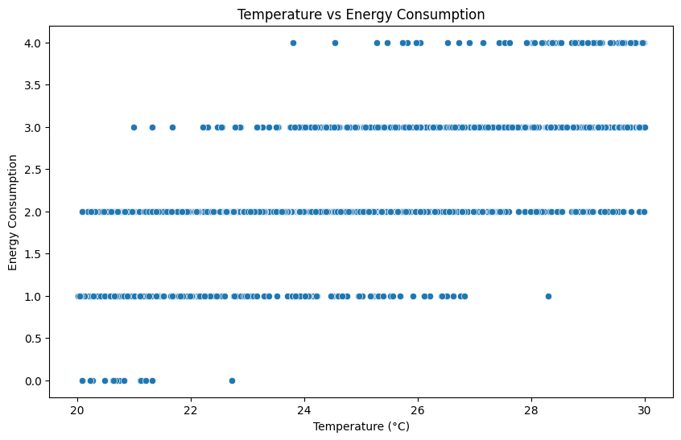

**Interpretation :** As temperature increases, energy consumption generally rises, with low and medium consumption observed at lower temperatures (20-23°C) and high to very high consumption at higher temperatures (25-30°C). This suggests a trend where higher temperatures lead to greater energy use, though some outliers are present that may require further exploration.

```python
import matplotlib.pyplot as plt
import seaborn as sns


plt.figure(figsize=(10,6))
sns.scatterplot(data=data, x='Temperature', y='EnergyConsumption_Category')
plt.title('Temperature vs Energy Consumption')
plt.xlabel('Temperature (°C)')
plt.ylabel('Energy Consumption')
plt.show()
```

### Prose for the Violin Plot :

#### The **violin plot visualizes the distribution of energy consumption categories across different occupancy levels**. **Occupancy is plotted on the x-axis, and energy consumption categories on the y-axis**. The plot highlights data distribution, density, and variations for each occupancy level.

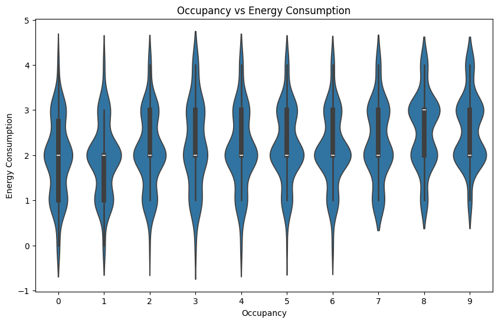

```python
plt.figure(figsize=(10,6))
sns.violinplot(data=data, x='Occupancy', y='EnergyConsumption_Category')
plt.title('Occupancy vs Energy Consumption')
plt.xlabel('Occupancy')
plt.ylabel('Energy Consumption')
plt.show()
```

### Prose for the Count Plot (Day of the week) :

#### This **code aggregates data by determining the dominant day for each observation using one-hot encoded columns.** The Day column is created by identifying the day with the highest value across all day-related columns.

#### **The count plot visualizes energy consumption categories for each day of the week. The x-axis represents days, while the y-axis shows the count of occurrences, with a hue distinguishing energy categories.**

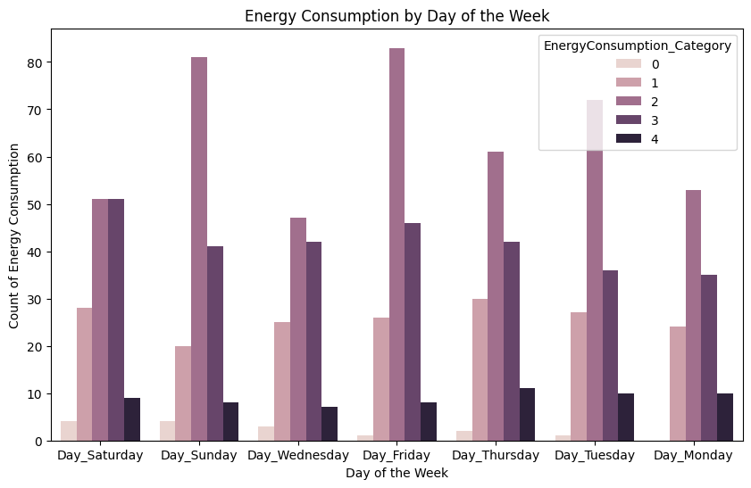

```python
# Aggregating data by day of the week
data['Day'] = data[['Day_Monday', 'Day_Tuesday', 'Day_Wednesday', 'Day_Thursday', 'Day_Friday', 'Day_Saturday', 'Day_Sunday']].idxmax(axis=1)

plt.figure(figsize=(10,6))
sns.countplot(data=data, x='Day', hue='EnergyConsumption_Category')
plt.title('Energy Consumption by Day of the Week')
plt.xlabel('Day of the Week')
plt.ylabel('Count of Energy Consumption')
plt.show()
```

```python
# converting time into hour no.
data['hour']=data['Time'].apply(lambda x:x[:2])
data.head()
```

|  | Temperature | Humidity | SquareFootage | Occupancy | HVACUsage | LightingUsage | RenewableEnergy | Holiday | EnergyConsumption_Category | Date | Time | Day_Friday | Day_Monday | Day_Saturday | Day_Sunday | Day_Thursday | Day_Tuesday | Day_Wednesday | Day | hour |
| --- | --- | --- | --- | --- | --- | --- | --- | --- | --- | --- | --- | --- | --- | --- | --- | --- | --- | --- | --- | --- |
| 0 | 27.731651 | 54.225919 | 1411.064918 | 1 | 1 | 1 | 21.831384 | 0 | 3 | 2022-01-01 | 01:00:00 | 0 | 0 | 1 | 0 | 0 | 0 | 0 | Day_Saturday | 01 |
| 1 | 28.704277 | 58.907658 | 1755.715009 | 2 | 0 | 0 | 6.764672 | 0 | 2 | 2022-01-01 | 02:00:00 | 0 | 0 | 0 | 1 | 0 | 0 | 0 | Day_Sunday | 02 |
| 2 | 20.080469 | 50.371637 | 1452.316318 | 1 | 0 | 1 | 8.623447 | 0 | 0 | 2022-01-01 | 03:00:00 | 0 | 0 | 0 | 0 | 0 | 0 | 1 | Day_Wednesday | 03 |
| 3 | 23.097359 | 51.401421 | 1094.130359 | 9 | 1 | 0 | 3.071969 | 0 | 2 | 2022-01-01 | 04:00:00 | 1 | 0 | 0 | 0 | 0 | 0 | 0 | Day_Friday | 04 |
| 4 | 29.576037 | 36.824263 | 1871.709180 | 6 | 0 | 0 | 17.626690 | 1 | 3 | 2022-01-01 | 05:00:00 | 0 | 0 | 0 | 1 | 0 | 0 | 0 | Day_Sunday | 05 |

### Prose for the Count Plot (Each hour a day) :

#### This code **creates a count plot to analyze energy consumption categories across different hours of the day. The x-axis represents the hours (0–23), and the y-axis shows the count of energy consumption instances, with hues distinguishing categories.**

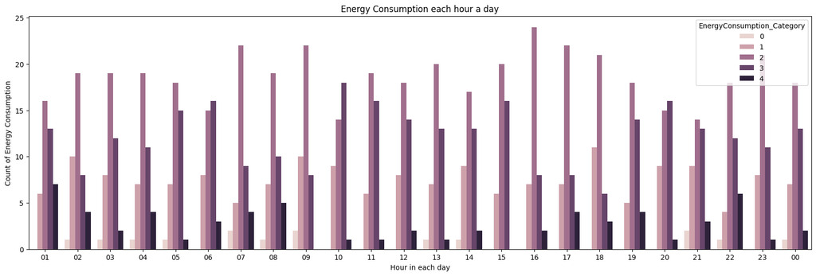

```python
plt.figure(figsize=(20,6))
sns.countplot(data=data, x='hour', hue='EnergyConsumption_Category')
plt.title('Energy Consumption each hour a day')
plt.xlabel('Hour in each day')
plt.ylabel('Count of Energy Consumption')
plt.show()
```

### Prose for the Heat Map :

#### The code **generates a correlation heatmap for numerical features** in the dataset. A s**ubset of numerical columns is selected, and their pairwise correlations are computed**. The heatmap, sized 12x6 inches, displays these correlations with annotations for precise values and a green color palette for visual appeal. **This visualization highlights relationships among variables, aiding in identifying features with strong correlations** to energy consumption categories or other attributes.

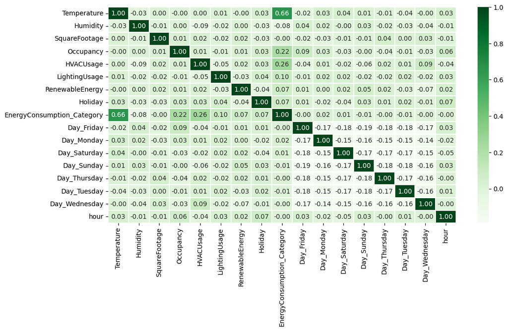

**Interpretation :**The heatmap shows the correlation matrix of various variables related to energy consumption. Energy consumption category is positively correlated with temperature (0.66), HVAC usage (0.26), and occupancy (0.22). This indicates that higher energy consumption is associated with higher temperatures, increased HVAC operations, and greater occupancy levels. Other variables, such as lighting usage, renewable energy, and holiday, show weaker correlations, suggesting minimal direct impact. Days of the week and hours also show low correlations, implying limited influence on energy consumption patterns.

```python
## Correlation Heatmap
numerical_data=data[['Temperature', 'Humidity', 'SquareFootage', 'Occupancy', 'HVACUsage',
       'LightingUsage', 'RenewableEnergy', 'Holiday', 'EnergyConsumption_Category','Day_Friday', 'Day_Monday', 'Day_Saturday',
       'Day_Sunday', 'Day_Thursday', 'Day_Tuesday', 'Day_Wednesday', 'hour']]
plt.figure(figsize=(12, 6))
sns.heatmap(numerical_data.corr(),annot=True,linewidth=0.2,cmap='Greens',fmt=".2f")
```

### Prose for the Histograms :

#### This **code generates histograms with kernel density estimates (KDE) for four features: Temperature, Humidity, SquareFootage, and RenewableEnergy. The histplot function plots the distribution of each variable with 50 bins and overlays a KDE** for a smooth curve representation. Each plot is displayed with a title indicating the respective feature. This visualization helps understand the distribution and spread of key numerical features in the dataset.

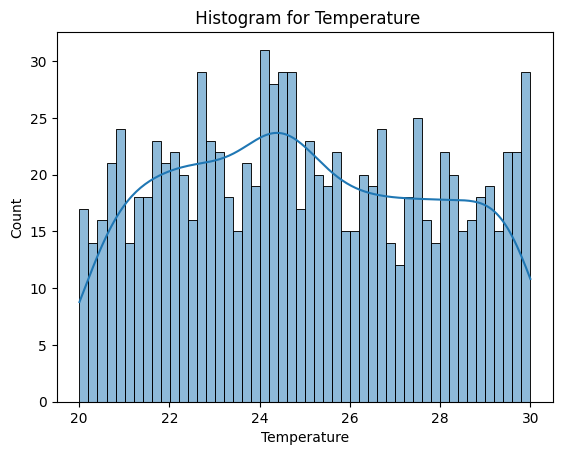

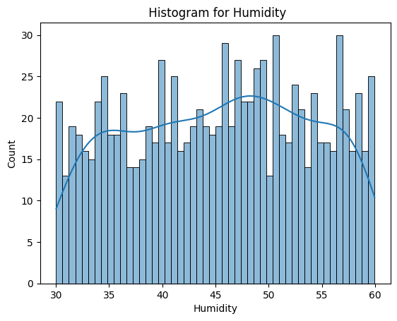

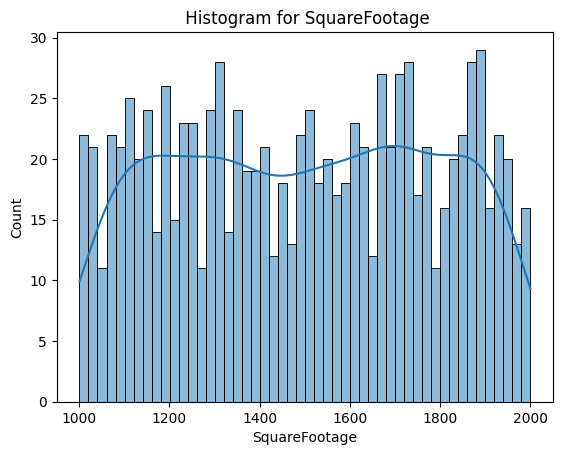

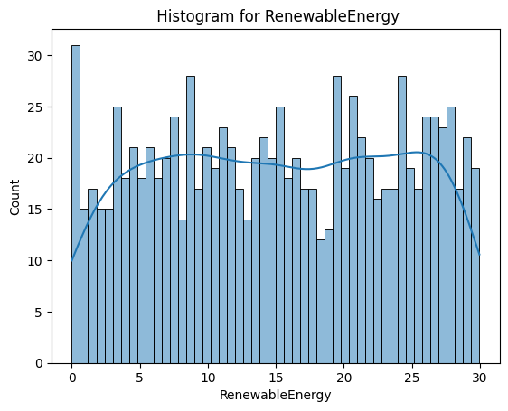

```python
cols=['Temperature', 'Humidity', 'SquareFootage',
        'RenewableEnergy']

for i in cols:
    sns.histplot(data[i],bins=50,kde=True)
    plt.title(f' Histogram for {i}')
    plt.show()
```

## STEP 4: Model Building

Now it’s time to bring the magic of **machine learning** into play! In this section, we dive into building and fine-tuning our models to predict energy consumption categories. First, we start with the **Random Forest Classifier**, using **GridSearchCV** to find the best hyperparameters and boost our model’s performance. Next, we step into the world of **deep learning** with an **LSTM model**, complete with **early stopping** and **dropout**. These tricks help us avoid overfitting while making the model smarter in understanding complex patterns. Finally, we take a more traditional approach with **Polynomial Logistic Regression**, using **L2 regularization** to keep things in check while we explore non-linear relationships in the data. Each model is tested, evaluated, and compared based on accuracy and other performance metrics.

```python
# Creating a copy of dataset

df = data.copy()
df.head()
```

[output not shown]

5 rows × 22 columns

```python
# dropping unnecessary columns and converting hour into integer value

df=df.drop(columns=['Date','Time','Day'])
df['hour']=df['hour'].astype('int64')
df.head()
```

|  | Temperature | Humidity | SquareFootage | Occupancy | HVACUsage | LightingUsage | RenewableEnergy | Holiday | EnergyConsumption_Category | Day_Friday | Day_Monday | Day_Saturday | Day_Sunday | Day_Thursday | Day_Tuesday | Day_Wednesday | hour | weekdays | weekends |
| --- | --- | --- | --- | --- | --- | --- | --- | --- | --- | --- | --- | --- | --- | --- | --- | --- | --- | --- | --- |
| 0 | 27.731651 | 54.225919 | 1411.064918 | 1 | 1 | 1 | 21.831384 | 0 | 3 | 0 | 0 | 1 | 0 | 0 | 0 | 0 | 1 | 0 | 1 |
| 1 | 28.704277 | 58.907658 | 1755.715009 | 2 | 0 | 0 | 6.764672 | 0 | 2 | 0 | 0 | 0 | 1 | 0 | 0 | 0 | 2 | 0 | 1 |
| 2 | 20.080469 | 50.371637 | 1452.316318 | 1 | 0 | 1 | 8.623447 | 0 | 0 | 0 | 0 | 0 | 0 | 0 | 0 | 1 | 3 | 1 | 0 |
| 3 | 23.097359 | 51.401421 | 1094.130359 | 9 | 1 | 0 | 3.071969 | 0 | 2 | 1 | 0 | 0 | 0 | 0 | 0 | 0 | 4 | 1 | 0 |
| 4 | 29.576037 | 36.824263 | 1871.709180 | 6 | 0 | 0 | 17.626690 | 1 | 3 | 0 | 0 | 0 | 1 | 0 | 0 | 0 | 5 | 0 | 1 |

### **Random Forest with GridSearchCV**

### Prose for the Random Forest Classifier :

#### This **code applies a Random Forest Classifier with GridSearchCV to optimize hyperparameters and build a robust classification model for predicting energy consumption categories**. The dataset is first split into features (X) and target (y), **with a train-test split of 80-20%. GridSearchCV is used to search for the best hyperparameters (like the number of estimators, max depth, and sample splits).**

#### After fitting the model, **the code evaluates performance using accuracy, classification report, and confusion matrix. It also visualizes feature importance to highlight which features influence** the predictions the most. **The optimization ensures the model achieves the best performance possible**, providing insights into energy consumption.

```
Best hyperparameters: {'max_depth': 10, 'min_samples_leaf': 1, 'min_samples_split': 10, 'n_estimators': 200}
Best cross-validation score: 0.5782547169811321
Accuracy: 0.56
Classification Report:
              precision    recall  f1-score   support

           0       0.00      0.00      0.00         3
           1       0.41      0.18      0.25        38
           2       0.61      0.71      0.66       100
           3       0.51      0.72      0.60        47
           4       0.00      0.00      0.00        12

    accuracy                           0.56       200
   macro avg       0.31      0.32      0.30       200
weighted avg       0.50      0.56      0.52       200

Confusion Matrix:
[[ 0  3  0  0  0]
 [ 0  7 31  0  0]
 [ 0  7 71 22  0]
 [ 0  0 13 34  0]
 [ 0  0  1 11  0]]
```

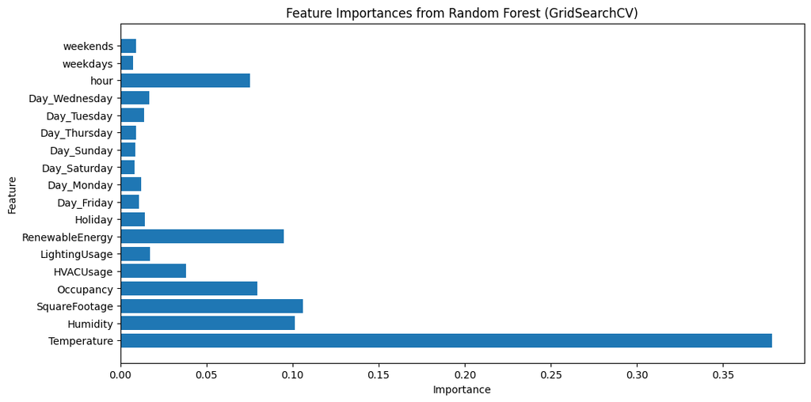

```python
# Applying Random Forest Classifier with GridSearchCV

from google.colab import drive
import matplotlib.pyplot as plt
import seaborn as sns
from sklearn.model_selection import train_test_split, GridSearchCV
from sklearn.ensemble import RandomForestClassifier
from sklearn.metrics import accuracy_score, classification_report, confusion_matrix
from sklearn.preprocessing import LabelEncoder


# ## Model Building with GridSearchCV
df = data.copy()
df = df.drop(columns=['Date', 'Time'])

X = df.drop(columns=['EnergyConsumption_Category', 'Day'])
y = df['EnergyConsumption_Category']

X_train, X_test, y_train, y_test = train_test_split(X, y, test_size=0.2, random_state=42)

# Define the parameter grid for GridSearchCV
param_grid = {
    'n_estimators': [50, 100, 200],
    'max_depth': [None, 10, 20],
    'min_samples_split': [2, 5, 10],
    'min_samples_leaf': [1, 2, 4]
}

# Create a RandomForestClassifier
rf = RandomForestClassifier(random_state=42)

# Create a GridSearchCV object
grid_search = GridSearchCV(estimator=rf, param_grid=param_grid, cv=5, scoring='accuracy', n_jobs=-1)

# Fit the GridSearchCV object to the training data
grid_search.fit(X_train, y_train)

# Get the best hyperparameters and best score
best_params = grid_search.best_params_
best_score = grid_search.best_score_

print(f"Best hyperparameters: {best_params}")
print(f"Best cross-validation score: {best_score}")

# Train a model with the best hyperparameters
best_rf = RandomForestClassifier(**best_params, random_state=42)
best_rf.fit(X_train, y_train)

# Evaluate the model
y_pred_rf = best_rf.predict(X_test)

print("Accuracy:", accuracy_score(y_test, y_pred_rf))
print("Classification Report:")
print(classification_report(y_test, y_pred_rf))
print("Confusion Matrix:")
print(confusion_matrix(y_test, y_pred_rf))

# Feature importance
importances = best_rf.feature_importances_
features = X.columns

plt.figure(figsize=(12, 6))
plt.barh(features, importances)
plt.title('Feature Importances from Random Forest (GridSearchCV)')
plt.xlabel('Importance')
plt.ylabel('Feature')
plt.show()
```

### **LSTM Model with Early Stopping and Dropout**

### Prose for the LSTM Model :

#### This code **applies an LSTM (Long Short-Term Memory) model with early stopping and dropout** to predict energy consumption categories. The dataset is first split into training and testing sets, followed by feature scaling using StandardScaler. LSTM requires reshaping the data into 3D format (samples, timesteps, features).

#### The **model is built with two LSTM layers and dropout regularization to prevent overfitting**. Early stopping is **implemented to halt training if the validation loss doesn't improve**, preventing overfitting and saving training time.

#### The model is **compiled with the Adam optimizer and sparse categorical cross-entropy loss**. It is **trained for up to 100 epochs, with early stopping ensuring the best model is selected**. After training, predictions are made on the test set, and performance is evaluated using accuracy and a classification report. This approach enables the model to effectively classify energy consumption categories while addressing overfitting concerns.

```python
## Applying LSTM Model with early stopping and Dropout

from sklearn.model_selection import train_test_split
from sklearn.preprocessing import StandardScaler
from tensorflow.keras.models import Sequential
from tensorflow.keras.layers import LSTM, Dense, Dropout
from tensorflow.keras.callbacks import EarlyStopping
from sklearn.metrics import accuracy_score, classification_report



X = df.drop(columns=['EnergyConsumption_Category'])
y = df['EnergyConsumption_Category']
X_train, X_test, y_train, y_test = train_test_split(X, y, test_size=0.2, random_state=42)

# Feature scaling
scaler = StandardScaler()
X_train = scaler.fit_transform(X_train)
X_test = scaler.transform(X_test)


# Reshape data for LSTM (samples, timesteps, features)
X_train = X_train.reshape(X_train.shape[0], 1, X_train.shape[1])
X_test = X_test.reshape(X_test.shape[0], 1, X_test.shape[1])


# Build the LSTM model
model = Sequential()
model.add(LSTM(units=50, return_sequences=True, input_shape=(X_train.shape[1], X_train.shape[2])))
model.add(Dropout(0.2))
model.add(LSTM(units=50))
model.add(Dropout(0.2))
model.add(Dense(units=5, activation='softmax')) # Assuming 5 output categories

# Compile the model
model.compile(optimizer='adam', loss='sparse_categorical_crossentropy', metrics=['accuracy'])

# Define early stopping
early_stopping = EarlyStopping(monitor='val_loss', patience=10, restore_best_weights=True)

# Train the model
history = model.fit(X_train, y_train, epochs=100, batch_size=32, validation_split=0.2, callbacks=[early_stopping])

# Make predictions
y_pred_lstm = np.argmax(model.predict(X_test), axis=1)


# Evaluate the model
accuracy = accuracy_score(y_test, y_pred_lstm)
print(f"Accuracy: {accuracy}")
print(classification_report(y_test, y_pred_lstm))
```

```
20/20 ━━━━━━━━━━━━━━━━━━━━ 3s 21ms/step - accuracy: 0.2969 - loss: 1.6000 - val_accuracy: 0.5375 - val_loss: 1.5687
20/20 ━━━━━━━━━━━━━━━━━━━━ 0s 8ms/step - accuracy: 0.5290 - loss: 1.5568 - val_accuracy: 0.5625 - val_loss: 1.5206
20/20 ━━━━━━━━━━━━━━━━━━━━ 0s 8ms/step - accuracy: 0.5244 - loss: 1.5036 - val_accuracy: 0.5750 - val_loss: 1.4502
20/20 ━━━━━━━━━━━━━━━━━━━━ 0s 7ms/step - accuracy: 0.5621 - loss: 1.4109 - val_accuracy: 0.5750 - val_loss: 1.3480
20/20 ━━━━━━━━━━━━━━━━━━━━ 0s 8ms/step - accuracy: 0.5307 - loss: 1.3267 - val_accuracy: 0.5625 - val_loss: 1.2281
20/20 ━━━━━━━━━━━━━━━━━━━━ 0s 7ms/step - accuracy: 0.5327 - loss: 1.2072 - val_accuracy: 0.5688 - val_loss: 1.1284
20/20 ━━━━━━━━━━━━━━━━━━━━ 0s 9ms/step - accuracy: 0.5372 - loss: 1.1285 - val_accuracy: 0.6125 - val_loss: 1.0520
20/20 ━━━━━━━━━━━━━━━━━━━━ 0s 8ms/step - accuracy: 0.5740 - loss: 1.0379 - val_accuracy: 0.6125 - val_loss: 1.0008
20/20 ━━━━━━━━━━━━━━━━━━━━ 0s 8ms/step - accuracy: 0.6002 - loss: 0.9486 - val_accuracy: 0.5875 - val_loss: 0.9614
20/20 ━━━━━━━━━━━━━━━━━━━━ 0s 8ms/step - accuracy: 0.5839 - loss: 0.9387 - val_accuracy: 0.5750 - val_loss: 0.9334
20/20 ━━━━━━━━━━━━━━━━━━━━ 0s 8ms/step - accuracy: 0.6246 - loss: 0.8894 - val_accuracy: 0.5875 - val_loss: 0.9148
20/20 ━━━━━━━━━━━━━━━━━━━━ 0s 9ms/step - accuracy: 0.5793 - loss: 0.9316 - val_accuracy: 0.5562 - val_loss: 0.9053
20/20 ━━━━━━━━━━━━━━━━━━━━ 0s 8ms/step - accuracy: 0.6112 - loss: 0.8672 - val_accuracy: 0.5813 - val_loss: 0.8944
20/20 ━━━━━━━━━━━━━━━━━━━━ 0s 8ms/step - accuracy: 0.6315 - loss: 0.8600 - val_accuracy: 0.5813 - val_loss: 0.8886
20/20 ━━━━━━━━━━━━━━━━━━━━ 0s 8ms/step - accuracy: 0.6187 - loss: 0.8564 - val_accuracy: 0.5875 - val_loss: 0.8838
20/20 ━━━━━━━━━━━━━━━━━━━━ 0s 8ms/step - accuracy: 0.5999 - loss: 0.8643 - val_accuracy: 0.6062 - val_loss: 0.8794
20/20 ━━━━━━━━━━━━━━━━━━━━ 0s 8ms/step - accuracy: 0.6206 - loss: 0.8412 - val_accuracy: 0.6125 - val_loss: 0.8805
20/20 ━━━━━━━━━━━━━━━━━━━━ 0s 8ms/step - accuracy: 0.6320 - loss: 0.7897 - val_accuracy: 0.6000 - val_loss: 0.8813
20/20 ━━━━━━━━━━━━━━━━━━━━ 0s 9ms/step - accuracy: 0.6074 - loss: 0.8113 - val_accuracy: 0.5875 - val_loss: 0.8848
20/20 ━━━━━━━━━━━━━━━━━━━━ 0s 10ms/step - accuracy: 0.6154 - loss: 0.7958 - val_accuracy: 0.5875 - val_loss: 0.8902
20/20 ━━━━━━━━━━━━━━━━━━━━ 0s 8ms/step - accuracy: 0.6036 - loss: 0.8507 - val_accuracy: 0.5813 - val_loss: 0.8887
20/20 ━━━━━━━━━━━━━━━━━━━━ 0s 9ms/step - accuracy: 0.6014 - loss: 0.8269 - val_accuracy: 0.5938 - val_loss: 0.8913
20/20 ━━━━━━━━━━━━━━━━━━━━ 0s 8ms/step - accuracy: 0.6074 - loss: 0.8454 - val_accuracy: 0.6062 - val_loss: 0.8917
20/20 ━━━━━━━━━━━━━━━━━━━━ 0s 9ms/step - accuracy: 0.6159 - loss: 0.8219 - val_accuracy: 0.5875 - val_loss: 0.8901
20/20 ━━━━━━━━━━━━━━━━━━━━ 0s 8ms/step - accuracy: 0.5853 - loss: 0.8199 - val_accuracy: 0.5625 - val_loss: 0.8909
20/20 ━━━━━━━━━━━━━━━━━━━━ 0s 8ms/step - accuracy: 0.6482 - loss: 0.7599 - val_accuracy: 0.5625 - val_loss: 0.9012
```

[output not shown]

```
7/7 ━━━━━━━━━━━━━━━━━━━━ 0s 34ms/step
Accuracy: 0.575
              precision    recall  f1-score   support

           0       0.00      0.00      0.00         3
           1       0.48      0.34      0.40        38
           2       0.64      0.70      0.67       100
           3       0.51      0.68      0.58        47
           4       0.00      0.00      0.00        12

    accuracy                           0.57       200
   macro avg       0.33      0.34      0.33       200
weighted avg       0.53      0.57      0.55       200
```

### **Logistic Regression with Polynomial features and L2 Regularization**

### Prose for the Logistic Regression :

#### This code **applies Polynomial Logistic Regression with L2 regularization** to classify energy consumption categories. First, the **features are scaled using StandardScaler, and polynomial features (degree 2) are generated to capture non-linear relationships**. The data is then split into training and test sets.

#### A Logistic Regression model with L2 regularization is used, where the **regularization strength is controlled by the parameter C**. The model is trained and **evaluated using accuracy, a classification report, and a confusion matrix**. Finally, the model's coefficients are visualized to understand the importance of different polynomial features. This approach **captures complex relationships in the data while controlling for overfitting.**

```
Accuracy: 0.55
Classification Report:
              precision    recall  f1-score   support

           0       0.33      0.33      0.33         3
           1       0.55      0.32      0.40        38
           2       0.61      0.65      0.63       100
           3       0.49      0.64      0.56        47
           4       0.25      0.17      0.20        12

    accuracy                           0.55       200
   macro avg       0.45      0.42      0.42       200
weighted avg       0.55      0.55      0.54       200

Confusion Matrix:
[[ 1  2  0  0  0]
 [ 1 12 24  1  0]
 [ 1  8 65 23  3]
 [ 0  0 14 30  3]
 [ 0  0  3  7  2]]
```

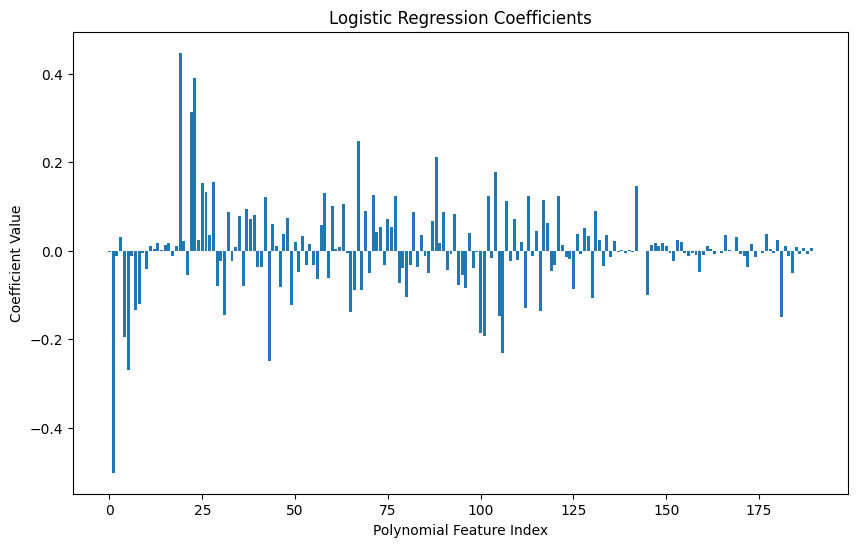

```python
## Applying Polynomial Logistic regression with L2 Regularization

from sklearn.model_selection import train_test_split
from sklearn.preprocessing import PolynomialFeatures, StandardScaler
from sklearn.linear_model import LogisticRegression
from sklearn.metrics import accuracy_score, classification_report, confusion_matrix
import matplotlib.pyplot as plt
import seaborn as sns



# Feature scaling
scaler = StandardScaler()
X = df.drop(columns=['EnergyConsumption_Category'])
y = df['EnergyConsumption_Category']

X_scaled = scaler.fit_transform(X)


# Polynomial feature generation
poly = PolynomialFeatures(degree=2) # Example: Degree 2 polynomial features
X_poly = poly.fit_transform(X_scaled)


# Split data into training and testing sets
X_train, X_test, y_train, y_test = train_test_split(X_poly, y, test_size=0.2, random_state=42)

# Logistic Regression with regularization (L2 penalty)
logreg = LogisticRegression(penalty='l2', C=0.1, solver='lbfgs', max_iter=1000) # Adjust C for regularization strength
logreg.fit(X_train, y_train)

# Predictions
y_pred_log_reg = logreg.predict(X_test)

# Evaluation metrics
print("Accuracy:", accuracy_score(y_test, y_pred_log_reg))
print("Classification Report:")
print(classification_report(y_test, y_pred_log_reg))
print("Confusion Matrix:")
print(confusion_matrix(y_test, y_pred_log_reg))


coefficients = logreg.coef_

# analyzing feature importance
plt.figure(figsize=(10, 6))
plt.bar(range(len(coefficients[0])), coefficients[0])
plt.xlabel("Polynomial Feature Index")
plt.ylabel("Coefficient Value")
plt.title("Logistic Regression Coefficients")
plt.show()
```

## The Accuracy of three models are respectively:

### Random Forest : 56 %

### LSTM : 57.5 %

### Logistic Regression : 55 %

### **Performing Hypothesis Testing between the results of the 3 models.**

### Prose for the code below

#### This code **performs the Kolmogorov-Smirnov (KS) test to compare the distributions of predictions from different models: Random Forest (RF), LSTM, and Logistic Regression**. The KS test **measures the maximum difference between the cumulative distributions of two datasets and is used to test whether the two distributions are significantly different.**

#### KS Test Comparisons:

##### **RF vs Logistic Regression**

##### **LSTM vs Logistic Regression**

#### Each pair is **evaluated by calculating the KS statistic and the p-value. If the p-value is less than the significance level (alpha = 0.05), it suggests a statistically significant difference in the distributions of predictions between the two models**. The results are printed accordingly, helping to assess the predictive consistency and divergence between the models.

```python
from scipy.stats import ks_2samp

#Perform Kolmogorov-Smirnov test for each pair of models.
#Compare Random Forest and LSTM
ks_statistic_rf_lstm, p_value_rf_lstm = ks_2samp(y_pred_rf, y_pred_lstm)
print(f"KS Statistic (RF vs LSTM): {ks_statistic_rf_lstm:.4f}")
print(f"P-value (RF vs LSTM): {p_value_rf_lstm:.4f}")

#Compare Random Forest and Logistic Regression
ks_statistic_rf_logreg, p_value_rf_logreg = ks_2samp(y_pred_rf, y_pred_log_reg)
print(f"KS Statistic (RF vs LogReg): {ks_statistic_rf_logreg:.4f}")
print(f"P-value (RF vs LogReg): {p_value_rf_logreg:.4f}")

#Compare LSTM and Logistic Regression
ks_statistic_lstm_logreg, p_value_lstm_logreg = ks_2samp(y_pred_lstm, y_pred_log_reg)
print(f"KS Statistic (LSTM vs LogReg): {ks_statistic_lstm_logreg:.4f}")
print(f"P-value (LSTM vs LogReg): {p_value_lstm_logreg:.4f}")


# Interpret the results
alpha = 0.05 # Significance level
for model1, model2, ks_statistic, p_value in [
    ("Random Forest", "LSTM", ks_statistic_rf_lstm, p_value_rf_lstm),
    ("Random Forest", "Logistic Regression", ks_statistic_rf_logreg, p_value_rf_logreg),
    ("LSTM", "Logistic Regression", ks_statistic_lstm_logreg, p_value_lstm_logreg)
]:
    if p_value < alpha:
        print(f"There is a statistically significant difference in the distributions of predictions between {model1} and {model2}")
    else:
        print(f"There is no statistically significant difference in the distributions of predictions between {model1} and {model2}")
```

```
KS Statistic (RF vs LSTM): 0.0500
P-value (RF vs LSTM): 0.9647
KS Statistic (RF vs LogReg): 0.0400
P-value (RF vs LogReg): 0.9973
KS Statistic (LSTM vs LogReg): 0.0350
P-value (LSTM vs LogReg): 0.9997
There is no statistically significant difference in the distributions of predictions between Random Forest and LSTM
There is no statistically significant difference in the distributions of predictions between Random Forest and Logistic Regression
There is no statistically significant difference in the distributions of predictions between LSTM and Logistic Regression
```

## Understanding and Conclusion

This project aimed to classify energy consumption categories based on various environmental and usage features, employing three distinct machine learning models: **Random Forest**, **LSTM**, and **Logistic Regression** with polynomial features and L2 regularization. Despite some challenges in achieving higher accuracy, the results highlight key insights into the performance of these models in a real-world energy consumption scenario. The **LSTM model** achieved an accuracy of **57.5%**, closely followed by **Random Forest** at **56%** and **Logistic Regression** at **55%**. While these accuracy scores might seem modest, they reflect the complexity and unpredictability of real-world datasets, where feature interactions and variability are difficult to capture. Given the variability inherent in energy consumption data—shaped by external factors like time of day, occupancy, and environmental conditions—these results are promising. Achieving **56-57%** accuracy in such a multifaceted domain shows that the models are capturing meaningful patterns, even if they are not perfect.

The challenges faced—such as achieving higher test accuracy despite hyperparameter tuning, regularization, and model improvements—are typical in real-world scenarios, where data quality, feature engineering, and model complexity often affect performance. In conclusion, the results of this project provide a solid foundation for future improvements. By exploring additional features, refining model architectures, and incorporating more sophisticated techniques, we can continue to improve prediction accuracy and advance toward more efficient and actionable energy management strategies.

[figure not shown]

Temperature

[figure not shown]

Humidity

[figure not shown]

Square footage

[figure not shown]

Occupancy

## References (Articles that might be helpful)

What is Kolomogorov Smirnov Test: When and Where to use it?

Learn more about L2 Regularization

Mathematical understanding of LSTM

Mathematical understanding of LSTM model

Learn More about Logistic Regression

Learn More about Random Forest